# Compositional Data

Adam Howes

## Statistical analysis of metagenomics data

Link: https://www.ncbi.nlm.nih.gov/pmc/articles/PMC6459172/pdf/gi-2019-17-1-e6.pdf

- Compositional data is of the form $x = (x_1, \ldots, x_k)$ such that $x_i > 0$ and $\sum_i x_i = T$
- The total $T$ is defined not to be of importance
- Equivalence to some member of the unit simplex $\mathcal{S} = \{x = (x_1, \ldots, x_k); \quad x_i > 0; \quad \sum_i x_i = 1\}$
- Desirata for CoDA
  - Permutation invariance: changing the order of the parts doesn’t matter
  - Scale invariance: any member of the equivalence class should have the same results
  - Sub-compositional coherence: results for a subset should be coherent with results for the whole composition
- Log-ratio $\log(x_i / x_j)$
- Log-contrast $\sum_i a_i \log(x_i); \quad \sum_i a_i = 0$
- Additive log-transformation $\text{alr}(x) = (\log(x_i / x_k))_{i < k}$
- Centered log-transformation $\text{clr}(x) = (\log(x_i / g(x)))_i$ where $g(x) = (\prod_i x_i)^{1 / k}$ is the geometric mean
- Isometric log-transformation (not described)
- Microbiome abundance table is a matrix $X$ with $n$ rows (samples) and $k$ columns (taxa) where each entry $x_ij$ provides the number of reads corresponding to taxon $j$ in sample $i$
- Other elements which could be available include the sample data, the taxonomy table, and the phylogenetic tree
- Alpha diversity: within sample diversity
- Richness $R_\text{obs}$ gives the number of species

## Visualizing the Multinomial in the Simplex

Link: http://www.statsathome.com/2017/09/14/visualizing-the-multinomial-in-the-simplex/

- The multinomial is a discretisation of the simplex
- The true value is $(.37, .37, .3)$ but there is no way to estimate that when the sample size is $n = 10$

```r
library(tidyverse)
library(driver)
library(combinat)
library(ggtern)
```

```r
plot_ternary_multinomial_density <- function(n, prob){
  sx <- t(xsimplex(p = 3, n = n))
  dx <- apply(sx, 1, function(x) dmultinom(x, size = n, prob = prob))
  sx <- cbind(as.data.frame(miniclo(sx)), dx)
  colnames(sx) <- c("v1", "v2", "v3", "d")

  s <- ggtern(sx, aes(x = v1, y = v2, z = v3)) +
    geom_point(alpha = 0.4, aes(size = d/max(d))) +
    theme_bw() +
    guides(size = FALSE) +
    scale_size(range = c(.1, 2))
  s
}
```

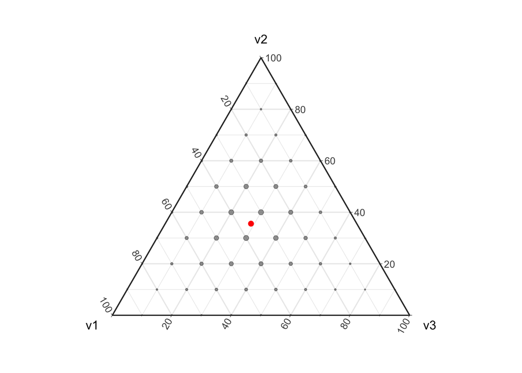

```r
prob <- miniclo(c(.37, .37, .3))
d <- setNames(as.data.frame(prob), c("v1", "v2", "v3"))
plot_ternary_multinomial_density(10, prob) +
  geom_point(data = d, color = "red", size = 2, fill = "red")
```

* As $n$ gets larger it’s easier to estimate $p$

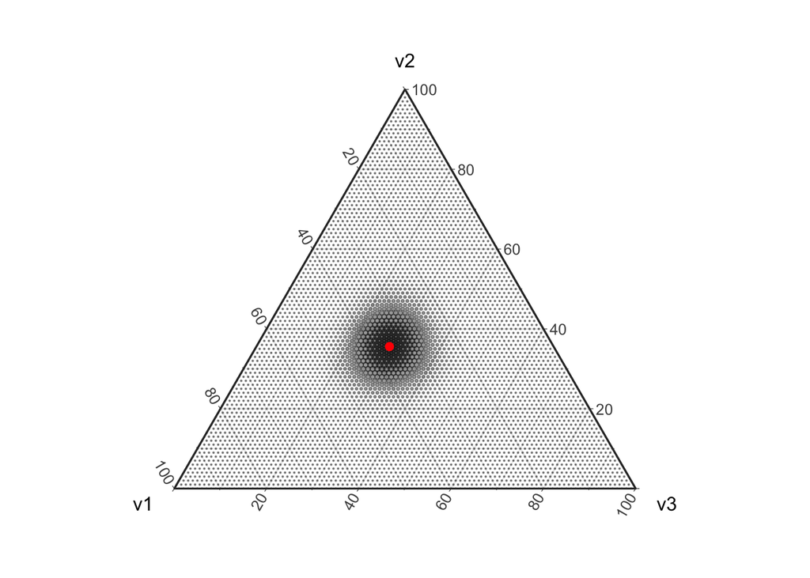

```r
d <- setNames(as.data.frame(prob), c("v1", "v2", "v3"))
plot_ternary_multinomial_density(100, prob) +
  geom_point(data = d, color = "red", size = 2, fill = "red")
```

* As $p$ gets smaller, it’s harder to estimate

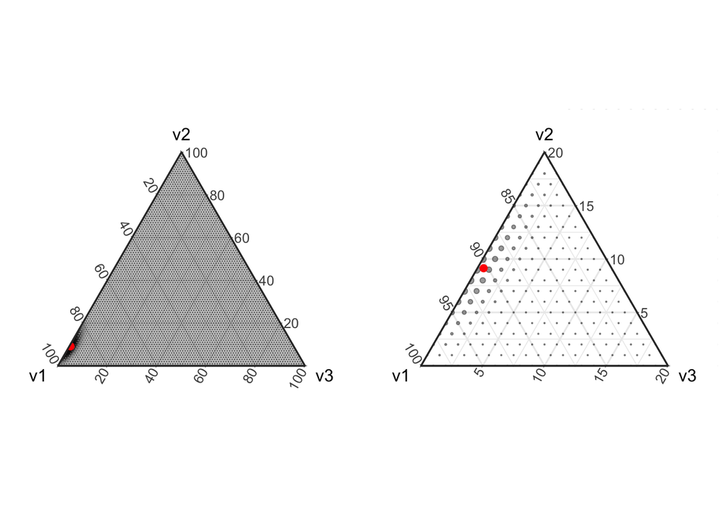

```r
prob <- miniclo(c(.9, .091, .005))
p1 <- plot_ternary_multinomial_density(100, prob) +
  geom_point(data=setNames(as.data.frame(prob), c("v1", "v2", "v3")), color = "red", size = 2, fill="red")
p2 <- p1 + theme_zoom_L(0.2)

grid.arrange(p1, p2, ncol=2)
```

## We can do better than the ALR or Softmax Transform

Link: http://www.statsathome.com/2017/08/09/we-can-do-better-than-the-alr-or-softmax-transform/

- The ALR transform corresponds to an oblique coordinate system in the simplex (i.e. it is not an orthogonal basis)

```r
library(compositions)
```

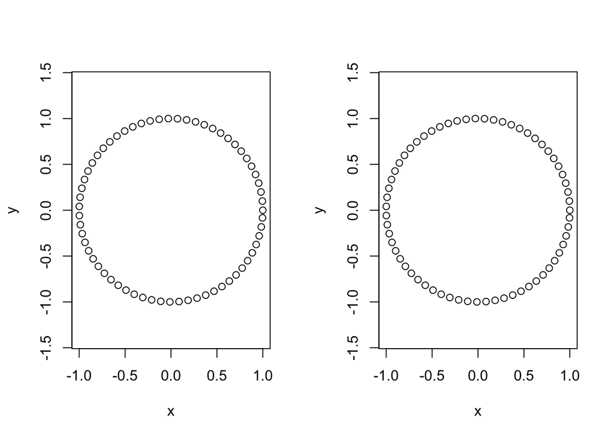

```r
t <- seq(0, 2 * pi, by = 0.1)
x <- cos(t)
y <- sin(t)
circ <- cbind(x, y)

par(mfrow = c(1, 2))
plot(circ, asp = 1)
plot(alr(alrInv(circ, 2), 3), asp = 1)
```

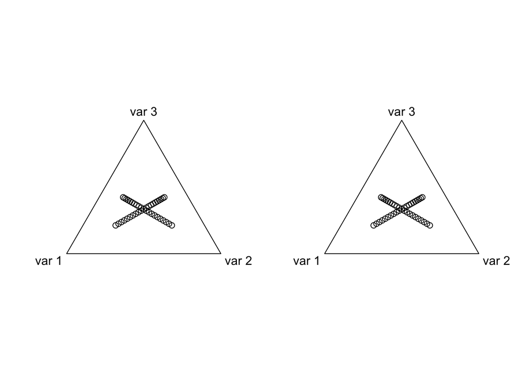

```r
coords <- as.matrix(rbind(
  cbind(0, seq(-1, 1, by = 0.1)),
  cbind(seq(-1, 1, by = 0.1), 0))
)

par(mfrow=c(1, 2))
plot(acomp(alrInv(coords, 2)))
plot(acomp(alrInv(coords, 3)))
```